# Computer Science 1

**Computer lab 03**

**Course Number:** BTPS1210BA-E  
**Contact Information:** Please contact me through email anytime: abari.kalman@arts.unideb.hu

Author

Kálmán Abari

Published

August 31, 2024

Learning outcomes

Students will learn how to manage bibliography.

# JabRef - Bibliography management

## Problem 1

> In this section, you will learn how to create BibTex file.

**Citation and BibTex format**

As you know, a “citation” is the way you tell your readers that certain material in your scientific work came from another source. It also gives your readers the information necessary to find that source again, including:

- information about the author
- the title of the work
- the name and location of the company that published your copy of the source
- the date your copy was published
- the page numbers of the material you are borrowing.

For example, reading an article you can see that it has **in-text citations** and that there is a **bibliography** at the end of the article. For example, in the PDF version of [this article](https://doi.org/10.3389/feduc.2021.630666):

[figure not shown]

[figure not shown]

*BibTeX* is a standard format to store bibliography items. BibTeX uses a style-independent text-based file format for lists of bibliography items (or lists of references), such as articles, books, and theses.

More information [here](https://medium.com/better-academic-writing/what-is-bibtex-and-how-you-can-use-it-in-academic-writing-1f41028ee7b8).

In-text citation

Bibliography

1. Visiting [The top 10 journal articles](https://www.apa.org/monitor/2018/12/top-journal-articles), let’s create a BibTex file, named `top_3.bib`, from the reference data of the first 3 ranked articles.
2. At the end of each paragraph, we find the DOI identifier of each article:
   - [DOI: 10.1037/amp0000151](http://dx.doi.org/10.1037/amp0000151)
   - [DOI: 10.1037/ppm0000182](http://psycnet.apa.org/fulltext/2018-15210-001.html)
   - [DOI: 10.1037/amp0000191](http://dx.doi.org/10.1037/amp0000191)

**Digital Object Identifier (DOI)**

A DOI (Digital Object Identifier) is a unique and never-changing string assigned to online (journal) articles, books, and other works. More information [here](https://www.doi.org/.

3. Open JabRef, and select `File / New library`, then save as `top_3.bib`.

[figure not shown]

Empty BibTex file

[figure not shown]

Saved file: `top_3.bib`

4. Select `New entry` button, and insert the first DOI link into edit box. Then, click on `Generate` button. You have created the firt bibliography item.

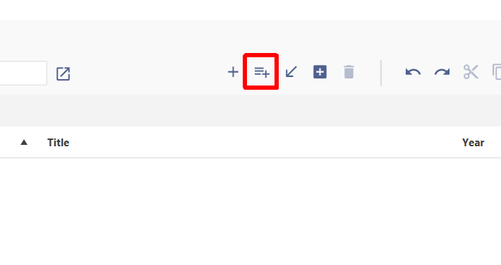

Select `New entry` button

[figure not shown]

Insert DOI link into edit box

[figure not shown]

BibTex file with one bibliography item

5. Let’s check that all the data in the article is correct. Double-click on the bibliography element, check the input fields on each tab.

[figure not shown]

Double-click on the bibliography element

6. Let’s check the following article characteristics: author, title, journal, year, citatonkey, volume, number, pages. Delete the field `Month`.

[figure not shown]

Input fields to check and modify

[figure not shown]

Delete the `Month` field

7. How does the BibTex file record a bibliographic item? You can view it on the `BibTex source` tab.

[figure not shown]

`BibTex source` tab

8. The most important field is the `Citationkey`, as it identifies the bibliographic element. It is important that it is unique to the entire bib file. Please double check that this field is filled in and note this ID. The citation key is `Levitt2018`.

[figure not shown]

`Citationkey` field

9. Close the panel containing the details of the bibliographic item.

[figure not shown]

Close the deatils panel

10. Repeat steps 4-9. points based on the DOI link of the second and third ranked article. Do not forget to delete the `Month` field and note the contents of the `Citationkey` field. These are the following for the three articles:
- `Levitt2018`
- `Sherlock2019`
- `Appelbaum2018`

[figure not shown]

3 articales in JabRef

13. Save and send the file `top_3.bib` to the `abari.kurzus@gmail.com`. The subject of this email is `Lab03 - Problem 1`.

## Problem 2

> In this section, you will learn how to manually insert elements into a BibTex file.

Select the top two from page [100 Greatest Psychology Books of All Time](https://www.aboutgreatbooks.com/topics/psychology/greatest-psychology-books-of-all-time/) and add them to the `top_3.bib` file. Save the file as `top_3_extended.bib`.

1. Record the bibliographic data of the first-placed book (*59 Seconds: Change Your Life in Under a Minute*). Visit the page above and proceed to the Amazon page, where you will also find the usual information for recording books:
   - author
   - title
   - year of publication
   - publisher.
2. Open `top_3.bib` file from Problem 1 in JabRef. Save the file as `top_3_extended.bib`. Select the `New article` button.

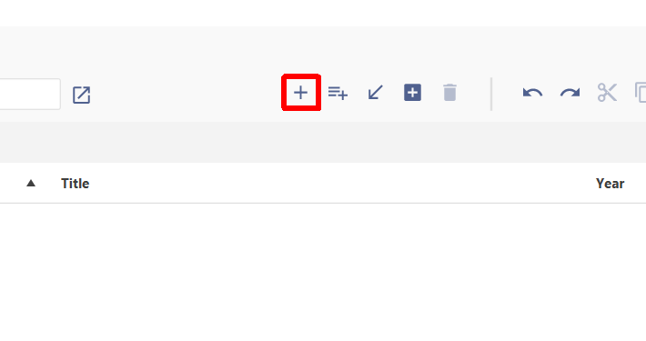

New article button

3. Change the bibliographic item type. By default it is `Article`, but since we are now creating a book, select `Book`.

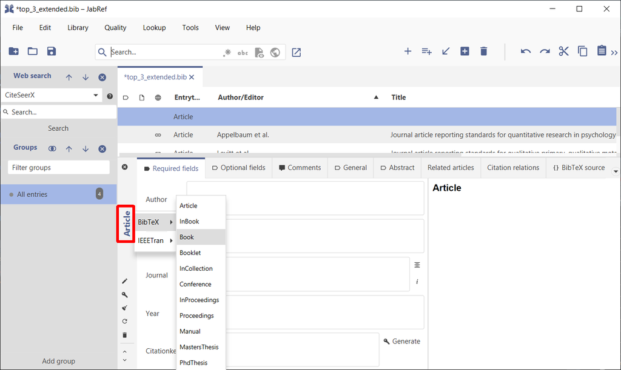

Change the type of item

4. Using the appropriate [page](https://www.amazon.com/gp/product/0307474860/ref=as_li_tl?ie=UTF8&tag=agb011-20&camp=1789&creative=9325&linkCode=as2&creativeASIN=0307474860&linkId=80964a600c210ad9c6d42a7bedabfb41) on Amazon, fill in the input fields with the help of the clipboard.
   - Author: Wiseman, Richard
   - Title: {59 Seconds: Change Your Life in Under a Minute}
     - For the proper appearance of the title (words starting with capital letters), it is recommended to surround the title with braces.
   - Year of publication: 2010
   - Publisher: Anchor

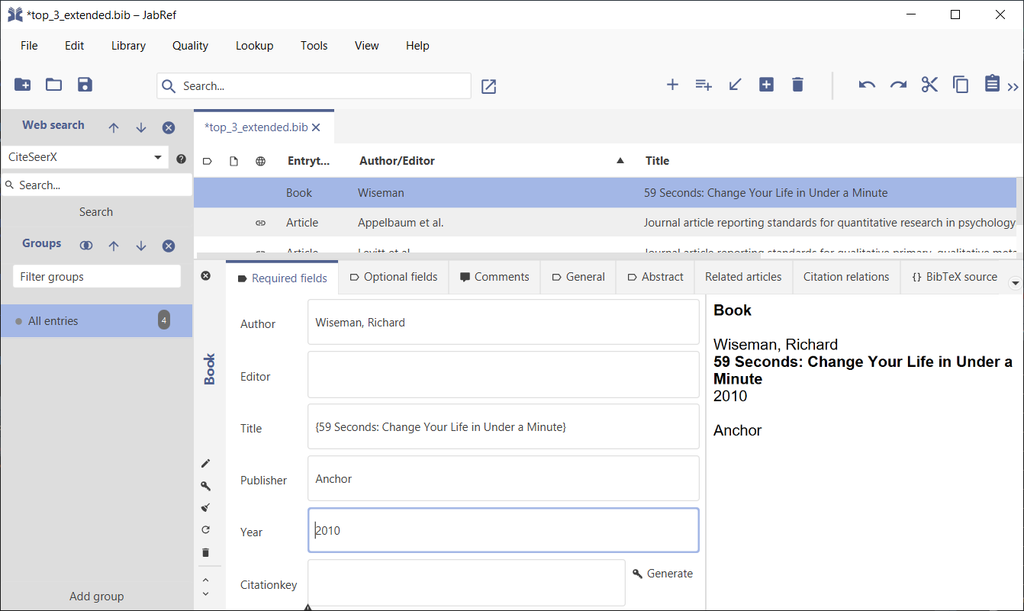

Information about a book

5. Every bibliographic item needs a `Citationkey`. Let’s generate a key and fix it if necessary. The key should be: `Wiseman2010`.

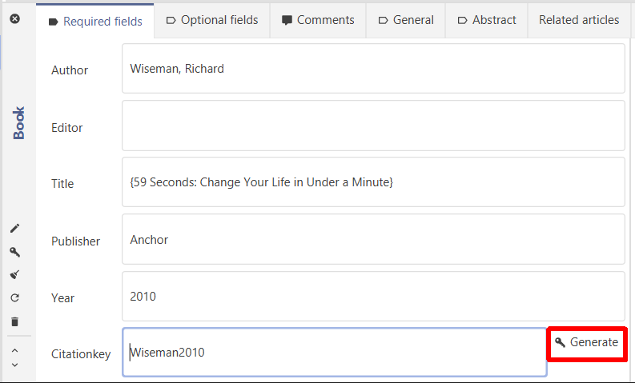

Generate citation key

6. To upload the second place book, search for the title of the book on [Google Books](https://books.google.com/). Type in the search box: “A Guide to Rational Living”.
7. Select the book [link](https://www.google.hu/books/edition/_/AP22zgEACAAJ) from the list of results.
8. Select the `Create citation` button on the page that appears and download the bibliographic information in BibTex format.

[figure not shown]

`Create citation` button

[figure not shown]

Download citation in BibTex format

9. Import the file you just downloaded into the `top_3_extended.bib` file. Select `File / Import / Import into current library` menu, and choose the `A_Guide_to_Rational_Living.bibtex` file.
10. Review the contents of the downloaded BibTex file in the Import dialog box. This file contains a single item. Select the `Import entries` button.

[figure not shown]

Import dialog box

11. Double-click on the book you just recorded and review the bibliographic information. We can see that the authors field is not filled in correctly.

[figure not shown]

Wrong authors

12. Change the contents of the `Author` field (in the case of two or more authors, use the word ‘and’):
    - Author: Ellis, Albert and Harper, Robert A.

[figure not shown]

Modify authors

13. Let’s also change the most important field, the `Citationkey` field. Have the content: `EllisHarper1975`.

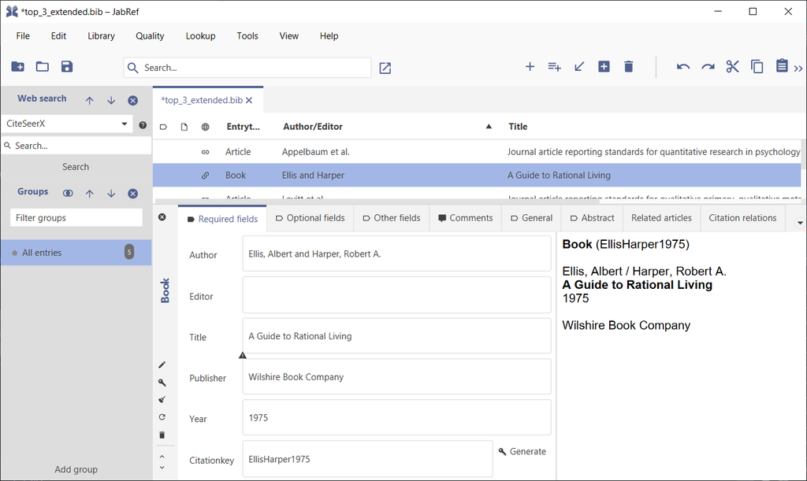

Modify `Citationkey`

14. The book *The Psychology of the Internet* provides a balanced overview of the psychological aspects of cyberspace. Finally, record this book data using one of the methods discussed above (`citationkey` should be `Wallace2015`.):
    - manually
    - based on DOI
    - import a previously downloaded BibTex file.

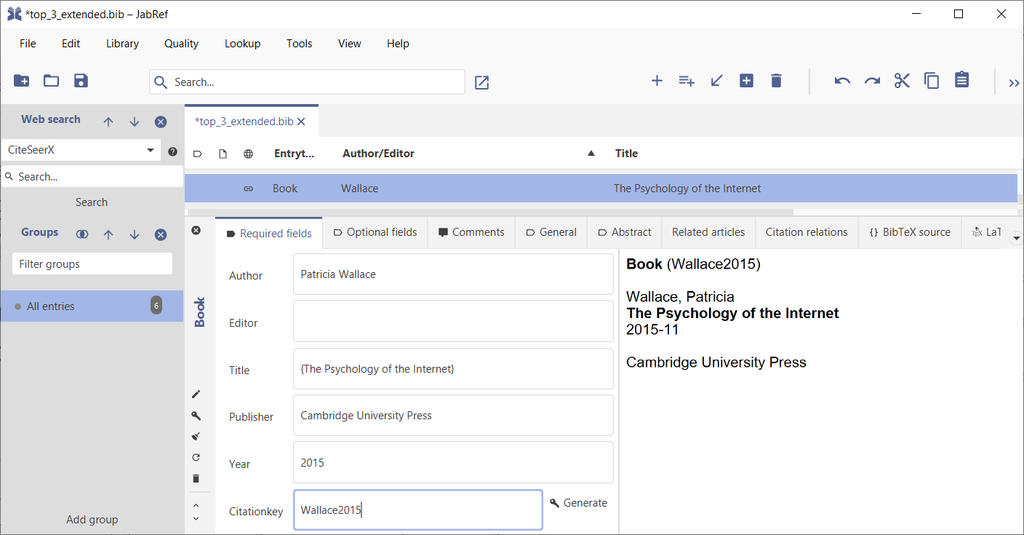

The book *The Psychology of the Internet*

13. Save and send the file `top_3_extended.bib` to the `abari.kurzus@gmail.com`. The subject of this email is `Lab03 - Problem 2`.

## Problem 3

> In this section, you will learn how to create a Quarto document with citation.

In Problem 2, we created a new BibTex file named `top_3_extended.bib`. It contains the following citation keys:

- `Levitt2018`
- `Sherlock2019`
- `Appelbaum2018`
- `Wiseman2010`
- `EllisHarper1975`
- `Wallace2015`.

Let’s create an HTML file that contains a paragraph in relation to all 6 sources (3 articles and 3 books) above, at the end of which we place an in-text citation, and we place a bibliography at the end of the HTML document.

1. Let’s create a new RStudio project called `citation`. Let’s also create a `citation.qmd` Quarto file.
2. Change the header of the Quarto document so that the HTML file to be created does not depend on external files, and also contains a table of contents. The header can be something like this:

```yaml
---
title: "The 6 best psychological works"
author: "Kálmán Abari"
format:
  html:
    embed-resources: true
    self-contained-math: true
toc: true
toc-depth: 2
title-block-banner: "#D5EDFF"
theme: cosmo
date:  "2023-10-08"
---
```

3. In order for our Quarto file to be able to display references (both for in-text citation and for the bibliography), we need two more external files and two more lines in the header of the Quarto document:
   - Copy the `top_3_extended.bib` file into the project directory and refer to it in the header with the following line:
     - `bibliography: top_3_extended.bib`
   - Download the APA7 CSL file (apa-annotated-bibliography.csl) responsible for the formal appearance of the citations and copy it into the project directory. Refer to it in the header with the following line:
     - `csl: apa-annotated-bibliography.csl`

The new header can be something like this:

```yaml
---
title: "The 6 best psychological works"
author: "Kálmán Abari"
format:
  html:
    embed-resources: true
    self-contained-math: true
toc: true
toc-depth: 2
title-block-banner: "#D5EDFF"
theme: cosmo
date:  "2023-10-08"
bibliography: top_3_extended.bib
csl: apa-annotated-bibliography.csl
---
```

4. In relation to the 3 articles and 3 books appearing in Problem 2, find a short paragraph of text at the end of which, before the point, add an in-text reference in the following form:
- `[@Levitt2018]`
- `[@Sherlock2019]`
- `[@Appelbaum2018]`
- `[@Wiseman2010]`
- `[@EllisHarper1975]`
- `[@Wallace2015]`.

The new Quarto document can be something like this:

```yaml
---
title: "The 6 best psychological works"
author: "Kálmán Abari"
format:
  html:
    embed-resources: true
    self-contained-math: true
toc: true
toc-depth: 2
title-block-banner: "#D5EDFF"
theme: cosmo
date:  "2023-10-08"
bibliography: top_3_extended.bib
csl: apa-annotated-bibliography.csl
---


# Top 3 articles

## Top 1

The American Psychological Association Publications and Communications Board Working Group on Journal Article Reporting Standards for Qualitative Research (JARS–Qual Working Group) was charged with examining the state of journal article reporting standards as they applied to qualitative research and with generating recommendations for standards that would be appropriate for a wide range of methods within the discipline of psychology [@Levitt2018].

## Top 2

Research on the mental health effects of social networking have predominantly focused on Facebook, with limited research investigating the effects of Instagram on psychological well-being. This study aimed to address the link between Instagram use and a range of psychological variables in two parts. Participants were 129 women aged between 18 and 35 years [@Sherlock2019].

## Top 3

The involvement of the American Psychological Association (APA) in the establishment of journal article reporting standards began as part of a mounting concern with transparency in science. The effort of the APA was contemporaneous with the development of reporting standards in other fields, such as the Consolidated Standards of Reporting Trials (CONSORT; see http://www.consort-statement.org/) in the medical sciences. Work on the APA standards began with the appointment of the first Working Group on Journal Article Reporting Standards (JARS) by the Publications and Communications (P&C) Board of APA in 2006 [@Appelbaum2018].


# Top 2 books

## 59 Seconds: Change Your Life in Under a Minute

In 59 Seconds: Change Your Life in Under a Minute psychologist and best-selling author Richard Wiseman outlines a myth dispelling alternative to the self-help movement. His book is filled with tips and tricks to improve your life, all stemming from solid scientific data. What led to the creation of this work was Wiseman’s troubled realization that the self-help industry often endorses exercises that minimize motivation, interfere with relationships, and limit creativity. 59 Seconds works against these limitations, uniting scientific advice can help individuals in need change their life almost immediately [@Wiseman2010].

## A Guide to Rational Living

Among all the books on this list, A Guide To Rational Living is one of the most popular books in the self-help/popular psychology category, selling over a million and a half copies since its publication. In this book, world-renowned psychologist Albert Ellis, along with colleagues Robert Harper and Melvin Powers, brought to public attention a new form of psychology called ‘rational emotive therapy’ (RET). This theory violated decades of traditional Freudian psychoanalysis and sparked a revolution in the field of psychology [@EllisHarper1975].

# The Psychology of the Internet

An engaging and research-based text, The Psychology of the Internet provides a balanced overview of the psychological aspects of cyberspace. It explores crucial questions about the internet's effects on human behavior, such as why we often act in uncharacteristic ways in online environments and how social media influence the impressions we form and our personal relationships [@Wallace2015].
```

5. At the end of the Quarto document, add the following lines so that the bibliography appears formatted:

```yaml
# References {.unnumbered}

::: {#refs}
:::
```

6. Save the QMD file and generate an HTML file, then send the file `citation.html` to the `abari.kurzus@gmail.com`. The subject of this email is `Lab03 - Problem 3`.